# Linear Regression: Model Specification, Comparison, and Interpretation

Predictors of Overall Favourability Rating

Author

Ronald Auguste

## Data Exploration

### Descriptive Statistics

Descriptive statistics for continuous variables

| variable | mean | sd | min | max |
| --- | --- | --- | --- | --- |
| rating | 64.63 | 12.17 | 40.00 | 85.00 |
| complaints | 66.60 | 13.31 | 37.00 | 90.00 |
| learning | 56.37 | 11.74 | 34.00 | 75.00 |
| raises | 64.63 | 10.40 | 43.00 | 88.00 |

### Distribution of overall rating

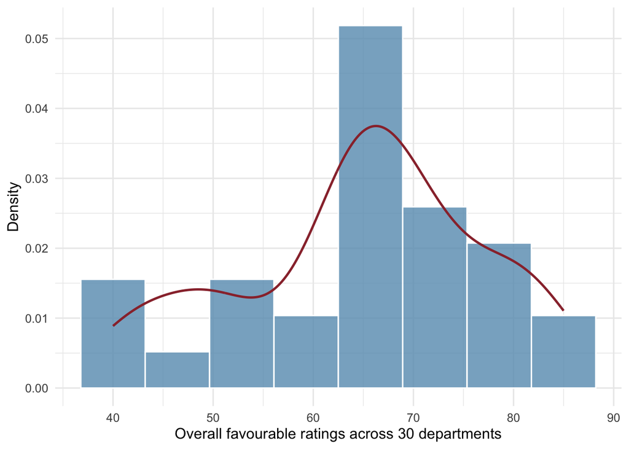

Distribution of overall rating percentages

### Relationships between predictors and overall rating

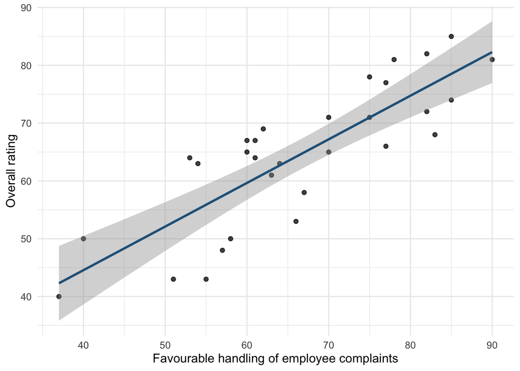

Relationship between complaints and overall rating

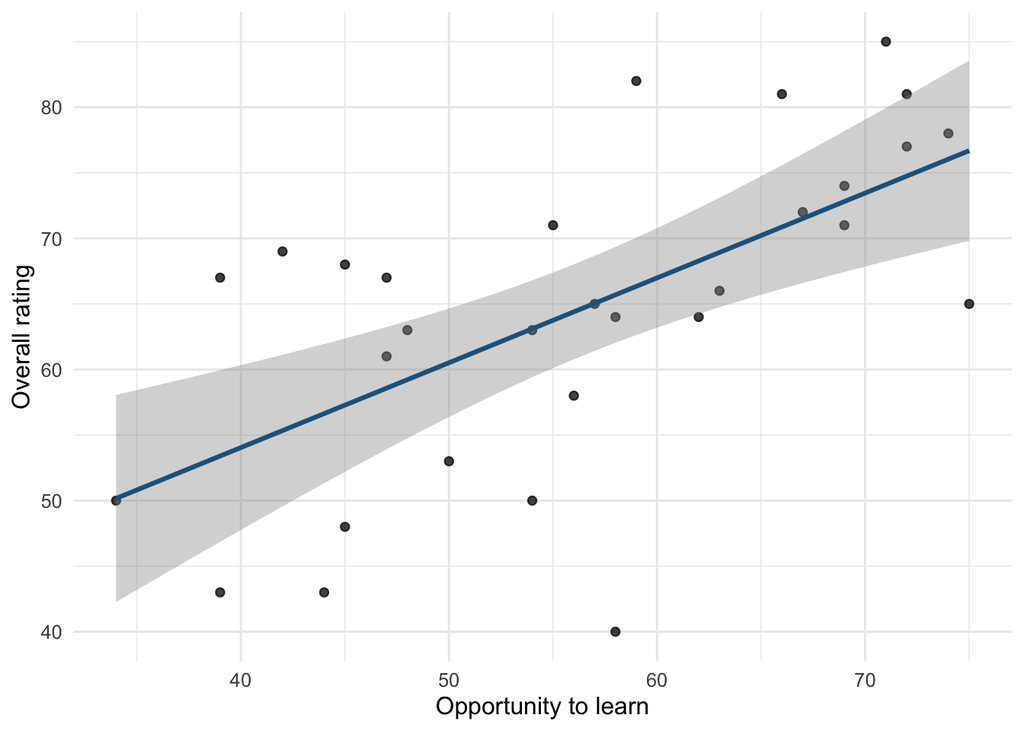

Relationship between learning and overall rating

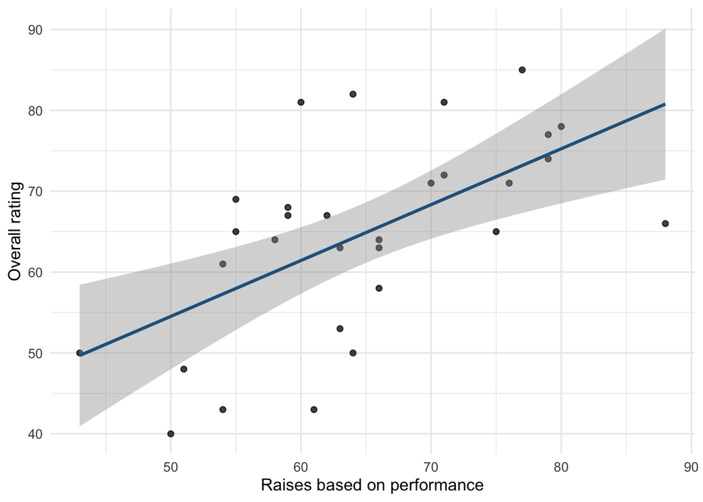

Relationship between raises and overall rating

From visual inspection of the scatterplots with fitted regression lines, the relationships with overall rating and the individual predictors appear relatively linear. In each of the three scatterplots, observations seem randomly dispersed above and below the fitted regression lines. The relationship between overall rating and handling of complaints appears to be the strongest, as observations tend to cluster closely around the line of best fit, whereas the relationships raises and learning show more scatter. There were no particularly unusual observations. These exploratory results are consistent with *a priori* expectations as all predictors should have a positive relationship with overall rating.

## Specification of competing regression models

### Predictions

On an individual level, favourable handling of employee complaints will tend to indicate that the department is considerate of employees’ well-being. As this scales up to the departmental level, it will engender a positive corporate culture, reflected in overall workplace ratings. The opposite is also likely true, therefore handling of employee complaints and overall ratings will have a positive relationship—the better the department is perceived to handle employee complaints, the better the overall rating. Opportunities for learning may also reflect consideration of employees’ well-being, albeit with some distinctiveness from handling of employee complaints. Opportunities for learning is likely to reflect a department’s focus on career enhancement and upward mobility for its employees, carrying a more long-term orientation than handling of complaints. For this reason, it may explain additional variation beyond complaint handling. Performance-based pay increases are also likely to explain further variation. Performance-based pay structures function fixed-ratio operant conditioning schedules, with clear connections between behaviour and reward. The incentive that this provides is likely to have a positive relationship with overall rating that is distinct from handling of employee complaints and opportunities for learning.

### Nested models

I will fit an intercept-only model and three increasingly complex substantive models.

| Model | Formula | Research rationale |
| --- | --- | --- |
| M0: Null | `rating ~ 1` | Baseline model |
| M1: Complaints | `rating ~ complaints` | Rating varies with complaints |
| M2: Complaints + Learning | `rating ~ complaints + learning` | Learning explains additional variation |
| M3: Expanded | `rating ~ complaints + learning + raises` | Raises explains additional variation |

The models are **nested**: each successive model contains all predictors from the preceding model, plus an additional predictor.

In **M1** the complaints coefficient refers to the estimated difference in overall rating for departments differing by 1 point in complaints,unadjusted for any other predictors. In **M2** the complaints coefficient refers to the estimated difference in overall rating for departments differing by 1 point in complaints, when learning is held constant. In **M3** the complaints coefficient refers to the estimated difference in overall rating for departments differing by 1 point in complaints, when learning and raises are held constant.

## Model Performance

### Model comparison table

Overall model performance and incremental nested-model comparisons

[output not shown]

### Interpreting the comparisons

Taken together, the model that includes complaints as the only predictor (M1: Complaints) appears to be the most appropriate for modelling overall ratings across departments. The following features support this conclusion: 1. It’s R2 is relatively high **(R² = .681)** and the overall model is statistically significant **F(1, 28) = 59.86, p < .001**. 2. Adjusted R2 values for subsequent models yield minimal increases, indicating that they do not materially explain additional variation. 3. Neither of the subsequent models produce statistically significant improvements in fit. 4. The reduction in root mean square error (RMSE) appears substantial from the null (intercept-only) model, showing a marked average reduction in the gap between fitted and observed overall rating values. Reductions in the more complex models are more modest and do not appear to be substantively meaningful.

## Evaluating regression diagnostics

### Examining assumptions

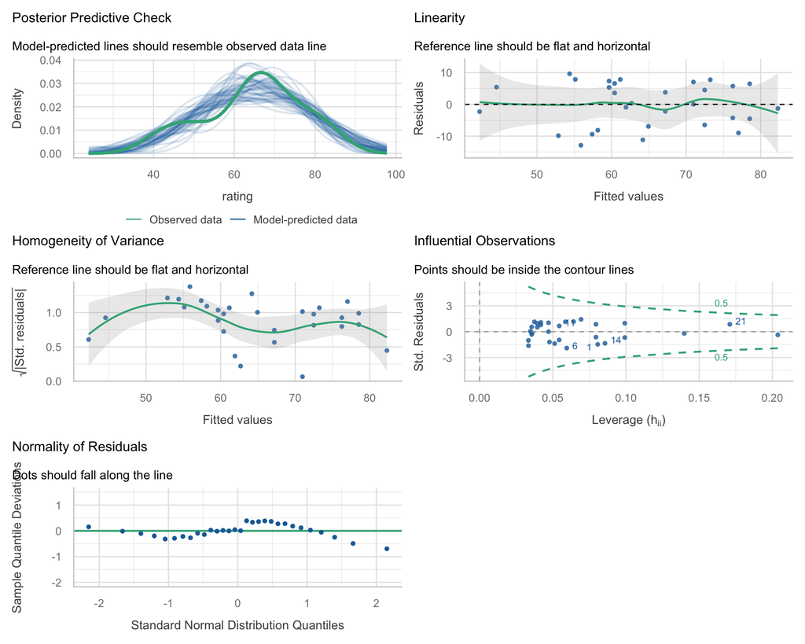

Regression diagnostic plots for the provisionally selected model

### Reporting findings

On examination of the regression diagnostic plots, all relevant assumptions appear to be reasonably satisfied. N.b. with only one predictor, the non-multicollinearity assumption does not apply. In the linearity plot, the smoothed reference line stays close to zero across the full range of fitted values, which indicates that a straight-line relationship between complaints and rating is appropriate. The homogeneity of variance plot shows no funnel-shaped pattern, so the residual spread is roughly constant across fitted values. All observations fall well within the Cook’s distance contours, so no single case unduly influences the estimates. The posterior predictive check also shows that model-simulated data broadly reproduce the observed distribution of ratings. However, a few minor irregularities are visible. The observed rating distribution has a small shoulder that the model does not capture, and the variance plot shows a slight hump at lower fitted values. The detrended Q-Q plot shows a mild wave pattern in which the most extreme residuals are somewhat smaller than a normal distribution would predict, which suggests slightly light tails. Two observations (e.g., department 21) also have relatively high leverage, but their small residuals mean they have little influence on the fit. These deviations are modest and consistent with sampling variability in a sample of about 30, and light-tailed residuals pose little threat to the validity of OLS standard errors and p-values. They therefore do not meaningfully reduce my confidence in the model’s estimates or inferences.

## Selection and reporting of preferred model

### Model selection

Based on overall performance, incremental performance and diagnostic findings, the model that includes complaints as the only predictor appears to be the most defensible representation of the relationship between workplace attitude variables and overall ratings across departments. In addition to the rationale stated previously, regression diagnostics also indicate that **M1: Complaints** is appropriate for modelling this relationship.

| Predictor | Estimate | SE | 95% CI lower | 95% CI upper | p |
| --- | --- | --- | --- | --- | --- |
| (Intercept) | 14.376 | 6.620 | 0.816 | 27.937 | 0.039 |
| complaints | 0.755 | 0.098 | 0.555 | 0.954 | < .001 |

### Interpreting coefficients

The coefficient for complaints is 0.75. Being the only predictor in the model, it is an unadjusted coefficient. It indicates that there is a positive relationship between favourable handling of complaints and overall ratings. Specifically, the coefficient indicates an estimated 0.75 higher percentage points in overall ratings between departments that differ by 1% in favourable handling of complaints. The 95% confidence interval for this average difference ranged from 0.55 to 0.95 percentage points. It excludes zero, so the data are inconsistent with no association.

### Summary of model performance

Overall performance of the selected model

| Model | R² | Adjusted R² | RMSE |
| --- | --- | --- | --- |
| M1: Complaints | 0.681 | 0.670 | 6.756 |

The R² indicates that the selected model (M1: Complaints) explains approximately 68.1% of the variation in overall ratings across departments within the sample. The adjusted R² is .670, and the RMSE is 6.76 percentage points. The RMSE describes the typical magnitude of the model’s fitted residuals on a root-mean-square scale. It should not be interpreted as an estimate of out-of-sample predictive accuracy.

## Findings and limitations

### Interpreting complaints

A 1-percentage-point higher rating of a department’s complaint handling is associated with an estimated 0.75-percentage-point higher overall rating, 95% CI [0.55, 0.95], p < .001. This analysis illustrates how overall ratings can be investigated using several competing regression models. The model-comparison process allows us to evaluate whether additional predictors explain meaningful variation beyond simpler models. The final model provides estimates of the associations between handling of complaints and overall ratings. However, several limitations should be recognized:

1. The observations describe department averages rather than individual people.
2. The data are self-report.
3. Regression coefficients represent associations rather than causal effects.
4. In-sample model performance does not establish out-of-sample predictive accuracy.